# Segundo Trabajo TAE

Angel David Machado

16/3/2020

### Capitulo 4

#### 10

Debemos de utilizar la base de datos Weekly, esta base de datos contiene información del rendimiento porcentual semanal para el índice bursátil S&P 500 entre 1990 y 2010.

```r
# Se carga la base de datoa a utilizar
library(ISLR)
```

```r
# Estadístico básicos
summary(Weekly)
```

```
##       Year           Lag1               Lag2               Lag3
##  Min.   :1990   Min.   :-18.1950   Min.   :-18.1950   Min.   :-18.1950
##  1st Qu.:1995   1st Qu.: -1.1540   1st Qu.: -1.1540   1st Qu.: -1.1580
##  Median :2000   Median :  0.2410   Median :  0.2410   Median :  0.2410
##  Mean   :2000   Mean   :  0.1506   Mean   :  0.1511   Mean   :  0.1472
##  3rd Qu.:2005   3rd Qu.:  1.4050   3rd Qu.:  1.4090   3rd Qu.:  1.4090
##  Max.   :2010   Max.   : 12.0260   Max.   : 12.0260   Max.   : 12.0260
##       Lag4               Lag5              Volume
##  Min.   :-18.1950   Min.   :-18.1950   Min.   :0.08747
##  1st Qu.: -1.1580   1st Qu.: -1.1660   1st Qu.:0.33202
##  Median :  0.2380   Median :  0.2340   Median :1.00268
##  Mean   :  0.1458   Mean   :  0.1399   Mean   :1.57462
##  3rd Qu.:  1.4090   3rd Qu.:  1.4050   3rd Qu.:2.05373
##  Max.   : 12.0260   Max.   : 12.0260   Max.   :9.32821
##      Today          Direction
##  Min.   :-18.1950   Down:484
##  1st Qu.: -1.1540   Up  :605
##  Median :  0.2410
##  Mean   :  0.1499
##  3rd Qu.:  1.4050
##  Max.   : 12.0260
```

Tenemos una base de datos con 1089 observaciones sobre las siguientes 9 variables.

- Year: El año en que se registró la observación.
- Lag1: Porcentaje de retorno de la semana anterior.
- Lag2: Porcentaje de retorno de 2 semanas anteriores
- Lag3: de retorno de 3 semanas anteriores
- Lag4: Porcentaje de retorno de 4 semanas anteriores
- Lag5: Porcentaje de retorno de 5 semanas anteriores
- Volume: Volumen de acciones negociadas (número promedio de acciones diarias negociadas en miles de millones)
- Today: Porcentaje de retorno para esta semana
- Direction: Un factor con niveles hacia abajo y hacia arriba que indica si el mercado tuvo un rendimiento positivo o negativo en una semana determinada

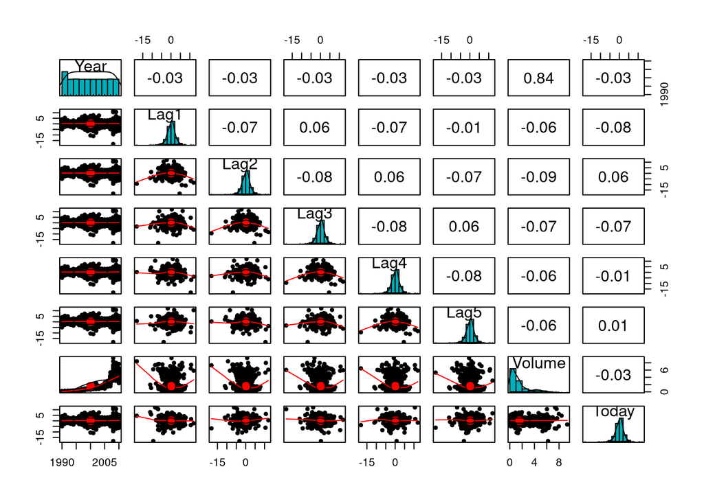

```r
library(psych)
# Gráfico de dispersión
pairs.panels(Weekly[,-9],
             method = "pearson",
             hist.col = "#00AFBB",
             density = TRUE,
             )
```

Como podemos apreciar, en general no pareciera que hubiesen muchas variables correlacionadas, pero si podemos apreciar una correlación positiva entre el año y la variable Volume. La variable volume hace referencia al volumen de acciones negociadas (número promedio de acciones diarias negociadas en miles de millones), por lo que a medida que pasa el tiempo, podemos apreciar como se aumenta también el volumen de acciones negociadas.

Le ejecutamos a todos los datos, utilizando Direction como la variable respuesta y las variables lag más la variable volume como predictoras, una regresión logística

```r
weeklyrlo <- glm(Direction ~ Lag1 + Lag2 + Lag3 + Lag4 + Lag5 + Volume, data = Weekly, family = "binomial")
summary(weeklyrlo)
```

```
##
## Call:
## glm(formula = Direction ~ Lag1 + Lag2 + Lag3 + Lag4 + Lag5 +
##     Volume, family = "binomial", data = Weekly)
##
## Deviance Residuals:
##     Min       1Q   Median       3Q      Max
## -1.6949  -1.2565   0.9913   1.0849   1.4579
##
## Coefficients:
##             Estimate Std. Error z value Pr(>|z|)
## (Intercept)  0.26686    0.08593   3.106   0.0019 **
## Lag1        -0.04127    0.02641  -1.563   0.1181
## Lag2         0.05844    0.02686   2.175   0.0296 *
## Lag3        -0.01606    0.02666  -0.602   0.5469
## Lag4        -0.02779    0.02646  -1.050   0.2937
## Lag5        -0.01447    0.02638  -0.549   0.5833
## Volume      -0.02274    0.03690  -0.616   0.5377
## ---
## Signif. codes:  0 '***' 0.001 '**' 0.01 '*' 0.05 '.' 0.1 ' ' 1
##
## (Dispersion parameter for binomial family taken to be 1)
##
##     Null deviance: 1496.2  on 1088  degrees of freedom
## Residual deviance: 1486.4  on 1082  degrees of freedom
## AIC: 1500.4
##
## Number of Fisher Scoring iterations: 4
```

Podemos apreciar que la variable lag2, es la única variables significativa.

```r
library("caret")
predichos=as.factor(ifelse(test = weeklyrlo$fitted.values > 0.5, yes = "Up", no = "Down"))
verdaderos=as.factor(Weekly$Direction)
matriz<-confusionMatrix(predichos, verdaderos)
matriz
```

```
## Confusion Matrix and Statistics
##
##           Reference
## Prediction Down  Up
##       Down   54  48
##       Up    430 557
##
##                Accuracy : 0.5611
##                  95% CI : (0.531, 0.5908)
##     No Information Rate : 0.5556
##     P-Value [Acc > NIR] : 0.369
##
##                   Kappa : 0.035
##
##  Mcnemar's Test P-Value : <2e-16
##
##             Sensitivity : 0.11157
##             Specificity : 0.92066
##          Pos Pred Value : 0.52941
##          Neg Pred Value : 0.56434
##              Prevalence : 0.44444
##          Detection Rate : 0.04959
##    Detection Prevalence : 0.09366
##       Balanced Accuracy : 0.51612
##
##        'Positive' Class : Down
##
```

|  | Reference |  |
| --- | --- | --- |
| Predicted | Down | Up |
| Down | A | B |
| Up | C | D |

```r
attach(Weekly)
w_entrenamiento <- (Year <= 2008)
```

```r
weeklyrlo2 <- glm(Direction ~ Lag2, data = Weekly, family = "binomial", subset = w_entrenamiento)
summary(weeklyrlo2)
```

```
##
## Call:
## glm(formula = Direction ~ Lag2, family = "binomial", data = Weekly,
##     subset = w_entrenamiento)
##
## Deviance Residuals:
##    Min      1Q  Median      3Q     Max
## -1.536  -1.264   1.021   1.091   1.368
##
## Coefficients:
##             Estimate Std. Error z value Pr(>|z|)
## (Intercept)  0.20326    0.06428   3.162  0.00157 **
## Lag2         0.05810    0.02870   2.024  0.04298 *
## ---
## Signif. codes:  0 '***' 0.001 '**' 0.01 '*' 0.05 '.' 0.1 ' ' 1
##
## (Dispersion parameter for binomial family taken to be 1)
##
##     Null deviance: 1354.7  on 984  degrees of freedom
## Residual deviance: 1350.5  on 983  degrees of freedom
## AIC: 1354.5
##
## Number of Fisher Scoring iterations: 4
```

```r
Weekly.20092010 <- Weekly[!w_entrenamiento, ]
Direction.20092010 <- Direction[!w_entrenamiento]

p <- predict(weeklyrlo2, Weekly.20092010, type = "response")
predichos=as.factor(ifelse(test = p > 0.5, yes = "Up", no = "Down"))
verdaderos=as.factor(Direction.20092010)
matriz<-confusionMatrix(predichos, verdaderos)
matriz
```

```
## Confusion Matrix and Statistics
##
##           Reference
## Prediction Down Up
##       Down    9  5
##       Up     34 56
##
##                Accuracy : 0.625
##                  95% CI : (0.5247, 0.718)
##     No Information Rate : 0.5865
##     P-Value [Acc > NIR] : 0.2439
##
##                   Kappa : 0.1414
##
##  Mcnemar's Test P-Value : 7.34e-06
##
##             Sensitivity : 0.20930
##             Specificity : 0.91803
##          Pos Pred Value : 0.64286
##          Neg Pred Value : 0.62222
##              Prevalence : 0.41346
##          Detection Rate : 0.08654
##    Detection Prevalence : 0.13462
##       Balanced Accuracy : 0.56367
##
##        'Positive' Class : Down
##
```

- Podemos apreciar que la precisión del modelo es de un 62.50%
- Cuando la semana del mercado es bajista, la precisión es de un 20.93%
- Cuando la semana del mercado es alcista, la precisión es de un 91.80%

```r
library(MASS)
ldapre <- lda(Direction ~ Lag2, data = Weekly, subset = w_entrenamiento)
ldapre
```

```
## Call:
## lda(Direction ~ Lag2, data = Weekly, subset = w_entrenamiento)
##
## Prior probabilities of groups:
##      Down        Up
## 0.4477157 0.5522843
##
## Group means:
##             Lag2
## Down -0.03568254
## Up    0.26036581
##
## Coefficients of linear discriminants:
##            LD1
## Lag2 0.4414162
```

```r
pred.lda <- predict(ldapre, Weekly.20092010)
verdaderos=as.factor(Direction.20092010)
matriz<-confusionMatrix(pred.lda$class, verdaderos)
matriz
```

```
## Confusion Matrix and Statistics
##
##           Reference
## Prediction Down Up
##       Down    9  5
##       Up     34 56
##
##                Accuracy : 0.625
##                  95% CI : (0.5247, 0.718)
##     No Information Rate : 0.5865
##     P-Value [Acc > NIR] : 0.2439
##
##                   Kappa : 0.1414
##
##  Mcnemar's Test P-Value : 7.34e-06
##
##             Sensitivity : 0.20930
##             Specificity : 0.91803
##          Pos Pred Value : 0.64286
##          Neg Pred Value : 0.62222
##              Prevalence : 0.41346
##          Detection Rate : 0.08654
##    Detection Prevalence : 0.13462
##       Balanced Accuracy : 0.56367
##
##        'Positive' Class : Down
##
```

- La precisión de este modelo es de 62.50%
- Cuando en la semana el mercado es bajista la precisión es de 20.93%
- Cuando en la semana el mercado es alcista la precisión es de 91.80%

```r
qdapre <- qda(Direction ~ Lag2, data = Weekly, subset = w_entrenamiento)
qdapre
```

```
## Call:
## qda(Direction ~ Lag2, data = Weekly, subset = w_entrenamiento)
##
## Prior probabilities of groups:
##      Down        Up
## 0.4477157 0.5522843
##
## Group means:
##             Lag2
## Down -0.03568254
## Up    0.26036581
```

```r
pred.qda <- predict(qdapre, Weekly.20092010)
matriz<-confusionMatrix(pred.qda$class, verdaderos)
matriz
```

```
## Confusion Matrix and Statistics
##
##           Reference
## Prediction Down Up
##       Down    0  0
##       Up     43 61
##
##                Accuracy : 0.5865
##                  95% CI : (0.4858, 0.6823)
##     No Information Rate : 0.5865
##     P-Value [Acc > NIR] : 0.5419
##
##                   Kappa : 0
##
##  Mcnemar's Test P-Value : 1.504e-10
##
##             Sensitivity : 0.0000
##             Specificity : 1.0000
##          Pos Pred Value :    NaN
##          Neg Pred Value : 0.5865
##              Prevalence : 0.4135
##          Detection Rate : 0.0000
##    Detection Prevalence : 0.0000
##       Balanced Accuracy : 0.5000
##
##        'Positive' Class : Down
##
```

- En este caso la predicción del modelo es de un 58.65%
- La precisión cuando es mercado es bajista es de un 0%
- La precisión cuando el mercado es alcista es de un 100%

```r
library(class)
entrenamiento.x <- as.matrix(Lag2[w_entrenamiento])
prueba.x <- as.matrix(Lag2[!w_entrenamiento])
entrenamiento.Direction <- Direction[w_entrenamiento]
pred.knn <- knn(entrenamiento.x, prueba.x, entrenamiento.Direction, k = 1)
confusionMatrix(pred.knn, Direction.20092010)
```

```
## Confusion Matrix and Statistics
##
##           Reference
## Prediction Down Up
##       Down   21 30
##       Up     22 31
##
##                Accuracy : 0.5
##                  95% CI : (0.4003, 0.5997)
##     No Information Rate : 0.5865
##     P-Value [Acc > NIR] : 0.9700
##
##                   Kappa : -0.0033
##
##  Mcnemar's Test P-Value : 0.3317
##
##             Sensitivity : 0.4884
##             Specificity : 0.5082
##          Pos Pred Value : 0.4118
##          Neg Pred Value : 0.5849
##              Prevalence : 0.4135
##          Detection Rate : 0.2019
##    Detection Prevalence : 0.4904
##       Balanced Accuracy : 0.4983
##
##        'Positive' Class : Down
##
```

- La precisión del modelo es de un 50%
- Cuando el mercado es bajista la precisión es de un 48.84%
- Cuando el mercado es alcista la precisión es de un 50.82%
8. Si analizamos las precisiones de los modelos obtuvimos los siguientes resultados:

|  | GLN | LDA | QDA | KNN |
| --- | --- | --- | --- | --- |
| Precisión | 62.5 | 62.5 | 58.65 | 50 |
| Sensitividad | 20.93 | 20.93 | 0 | 48.84 |
| Especificidad | 91.80 | 91.80 | 100 | 50.82 |

Por lo que podemos concluir que tanto el modelo GLN como LDA fueron los que mejor resultados dieron.

A continuación evaluamos KNN con los valores de K = 10, 20, 50 y 100

```r
# Para K = 10
pred.knn <- knn(entrenamiento.x, prueba.x, entrenamiento.Direction, k = 10)
z <-confusionMatrix(pred.knn, Direction.20092010)
z$table
```

```
##           Reference
## Prediction Down Up
##       Down   19 21
##       Up     24 40
```

```
## [1] "Accuracy: 0.5673 Sensitivity: 0.4419 Specificity: 0.6557"
```

```r
# Para k = 20
pred.knn <- knn(entrenamiento.x, prueba.x, entrenamiento.Direction, k = 20)
z <-confusionMatrix(pred.knn, Direction.20092010)
z$table
```

```
##           Reference
## Prediction Down Up
##       Down   20 19
##       Up     23 42
```

```
## [1] "Accuracy: 0.5962 Sensitivity: 0.4651 Specificity: 0.6885"
```

```r
# Para k = 50
pred.knn <- knn(entrenamiento.x, prueba.x, entrenamiento.Direction, k = 50)
z <-confusionMatrix(pred.knn, Direction.20092010)
z$table
```

```
##           Reference
## Prediction Down Up
##       Down   20 22
##       Up     23 39
```

```
## [1] "Accuracy: 0.5673 Sensitivity: 0.4651 Specificity: 0.6393"
```

```r
# Para k = 50
pred.knn <- knn(entrenamiento.x, prueba.x, entrenamiento.Direction, k = 100)
z <-confusionMatrix(pred.knn, Direction.20092010)
z$table
```

```
##           Reference
## Prediction Down Up
##       Down   10 11
##       Up     33 50
```

```
## [1] "Accuracy: 0.5769 Sensitivity: 0.2326 Specificity: 0.8197"
```

Ahora probaremos una regresión logística con las diferentes configuraciones de variables predictoras: volume, lag2 + lag3, lag1 + lg2, lag1 + lag2 + volume

```r
# para volume
weeklyrlo2 <- glm(Direction ~ Volume, data = Weekly, family = "binomial", subset = w_entrenamiento)
p <- predict(weeklyrlo2, Weekly.20092010, type = "response")
predichos=as.factor(ifelse(test = p > 0.5, yes = "Up", no = "Down"))
verdaderos=as.factor(Direction.20092010)
matriz<-confusionMatrix(predichos, verdaderos)
matriz$table
```

```
##           Reference
## Prediction Down Up
##       Down   31 47
##       Up     12 14
```

```
## [1] "Accuracy: 0.4327 Sensitivity: 0.7209 Specificity: 0.2295"
```

```r
# para lag2 + lag3
weeklyrlo2 <- glm(Direction ~ Lag2 + Lag3, data = Weekly, family = "binomial", subset = w_entrenamiento)
p <- predict(weeklyrlo2, Weekly.20092010, type = "response")
predichos=as.factor(ifelse(test = p > 0.5, yes = "Up", no = "Down"))
verdaderos=as.factor(Direction.20092010)
matriz<-confusionMatrix(predichos, verdaderos)
matriz$table
```

```
##           Reference
## Prediction Down Up
##       Down    8  4
##       Up     35 57
```

```
## [1] "Accuracy: 0.625 Sensitivity: 0.186 Specificity: 0.9344"
```

```r
# para lag1 + lag2
weeklyrlo2 <- glm(Direction ~ Lag1 + Lag2, data = Weekly, family = "binomial", subset = w_entrenamiento)
p <- predict(weeklyrlo2, Weekly.20092010, type = "response")
predichos=as.factor(ifelse(test = p > 0.5, yes = "Up", no = "Down"))
verdaderos=as.factor(Direction.20092010)
matriz<-confusionMatrix(predichos, verdaderos)
matriz$table
```

```
##           Reference
## Prediction Down Up
##       Down    7  8
##       Up     36 53
```

```
## [1] "Accuracy: 0.5769 Sensitivity: 0.1628 Specificity: 0.8689"
```

```r
# para lag1 + lag2 + volume
weeklyrlo2 <- glm(Direction ~ Lag1 +  Lag2 + Volume, data = Weekly, family = "binomial", subset = w_entrenamiento)
p <- predict(weeklyrlo2, Weekly.20092010, type = "response")
predichos=as.factor(ifelse(test = p > 0.5, yes = "Up", no = "Down"))
verdaderos=as.factor(Direction.20092010)
matriz<-confusionMatrix(predichos, verdaderos)
matriz$table
```

```
##           Reference
## Prediction Down Up
##       Down   27 33
##       Up     16 28
```

```
## [1] "Accuracy: 0.5288 Sensitivity: 0.6279 Specificity: 0.459"
```

Ahora probaremos una LDA con las diferentes configuraciones de variables predictoras: volume, lag2 + lag3, lag1 + lg2, lag1 + lag2 + volume

```r
# Para volume
ldapre <- lda(Direction ~ Volume, data = Weekly, subset = w_entrenamiento)
pred.lda <- predict(ldapre, Weekly.20092010)
matriz<-confusionMatrix(pred.lda$class, verdaderos)
matriz$table
```

```
##           Reference
## Prediction Down Up
##       Down   33 47
##       Up     10 14
```

```
## [1] "Accuracy: 0.4519 Sensitivity: 0.7674 Specificity: 0.2295"
```

```r
# Para lag2 + lag3
ldapre <- lda(Direction ~ Lag2 + Lag3, data = Weekly, subset = w_entrenamiento)
pred.lda <- predict(ldapre, Weekly.20092010)
matriz<-confusionMatrix(pred.lda$class, verdaderos)
matriz$table
```

```
##           Reference
## Prediction Down Up
##       Down    8  4
##       Up     35 57
```

```
## [1] "Accuracy: 0.625 Sensitivity: 0.186 Specificity: 0.9344"
```

```r
# Para lag1 + lag2
ldapre <- lda(Direction ~ Lag1 + Lag2, data = Weekly, subset = w_entrenamiento)
pred.lda <- predict(ldapre, Weekly.20092010)
matriz<-confusionMatrix(pred.lda$class, verdaderos)
matriz$table
```

```
##           Reference
## Prediction Down Up
##       Down    7  8
##       Up     36 53
```

```
## [1] "Accuracy: 0.5769 Sensitivity: 0.1628 Specificity: 0.8689"
```

```r
# Para lag1 + lag2 + volume
ldapre <- lda(Direction ~ Lag1 + Lag2 + Volume, data = Weekly, subset = w_entrenamiento)
pred.lda <- predict(ldapre, Weekly.20092010)
matriz<-confusionMatrix(pred.lda$class, verdaderos)
matriz$table
```

```
##           Reference
## Prediction Down Up
##       Down   27 33
##       Up     16 28
```

```
## [1] "Accuracy: 0.5288 Sensitivity: 0.6279 Specificity: 0.459"
```

Ahora probaremos una QDA con las diferentes configuraciones de variables predictoras: volume, lag2 + lag3, lag1 + lg2, lag1 + lag2 + volume

```r
# para volume
qdapre <- qda(Direction ~ Volume, data = Weekly, subset = w_entrenamiento)
pred.qda <- predict(qdapre, Weekly.20092010)
matriz<-confusionMatrix(pred.qda$class, verdaderos)
matriz$table
```

```
##           Reference
## Prediction Down Up
##       Down   43 59
##       Up      0  2
```

```r
imprimirASS(matriz)
```

```
## [1] "Accuracy: 0.4327 Sensitivity: 1 Specificity: 0.0328"
```

```r
# para lag2 + lag3
qdapre <- qda(Direction ~ Lag2 + Lag3, data = Weekly, subset = w_entrenamiento)
pred.qda <- predict(qdapre, Weekly.20092010)
matriz<-confusionMatrix(pred.qda$class, verdaderos)
matriz$table
```

```
##           Reference
## Prediction Down Up
##       Down    4  2
##       Up     39 59
```

```r
imprimirASS(matriz)
```

```
## [1] "Accuracy: 0.6058 Sensitivity: 0.093 Specificity: 0.9672"
```

```r
# para lag1 + lag2
qdapre <- qda(Direction ~ Lag1 + Lag2, data = Weekly, subset = w_entrenamiento)
pred.qda <- predict(qdapre, Weekly.20092010)
matriz<-confusionMatrix(pred.qda$class, verdaderos)
matriz$table
```

```
##           Reference
## Prediction Down Up
##       Down    7 10
##       Up     36 51
```

```r
imprimirASS(matriz)
```

```
## [1] "Accuracy: 0.5577 Sensitivity: 0.1628 Specificity: 0.8361"
```

```r
# para lag1 + lag2 + volume
qdapre <- qda(Direction ~ Lag1 + Lag2 + Volume, data = Weekly, subset = w_entrenamiento)
pred.qda <- predict(qdapre, Weekly.20092010)
matriz<-confusionMatrix(pred.qda$class, verdaderos)
matriz$table
```

```
##           Reference
## Prediction Down Up
##       Down   31 44
##       Up     12 17
```

```r
imprimirASS(matriz)
```

```
## [1] "Accuracy: 0.4615 Sensitivity: 0.7209 Specificity: 0.2787"
```

#### 11

```r
Auto <- Auto[c(-10,-11,-12,-13,-14,-15,-16,-17,-18)]
mpg01 <- rep(0, length(Auto$mpg))
mpg01[Auto$mpg > median(Auto$mpg)] <- 1
Auto <- data.frame(Auto, mpg01)
```

```r
str(Auto)
```

```
## 'data.frame':    392 obs. of  10 variables:
##  $ mpg         : num  18 15 18 16 17 15 14 14 14 15 ...
##  $ cylinders   : num  8 8 8 8 8 8 8 8 8 8 ...
##  $ displacement: num  307 350 318 304 302 429 454 440 455 390 ...
##  $ horsepower  : num  130 165 150 150 140 198 220 215 225 190 ...
##  $ weight      : num  3504 3693 3436 3433 3449 ...
##  $ acceleration: num  12 11.5 11 12 10.5 10 9 8.5 10 8.5 ...
##  $ year        : num  70 70 70 70 70 70 70 70 70 70 ...
##  $ origin      : num  1 1 1 1 1 1 1 1 1 1 ...
##  $ name        : Factor w/ 304 levels "amc ambassador brougham",..: 49 36 231 14 161 141 54 223 241 2 ...
##  $ mpg01       : num  0 0 0 0 0 0 0 0 0 0 ...
```

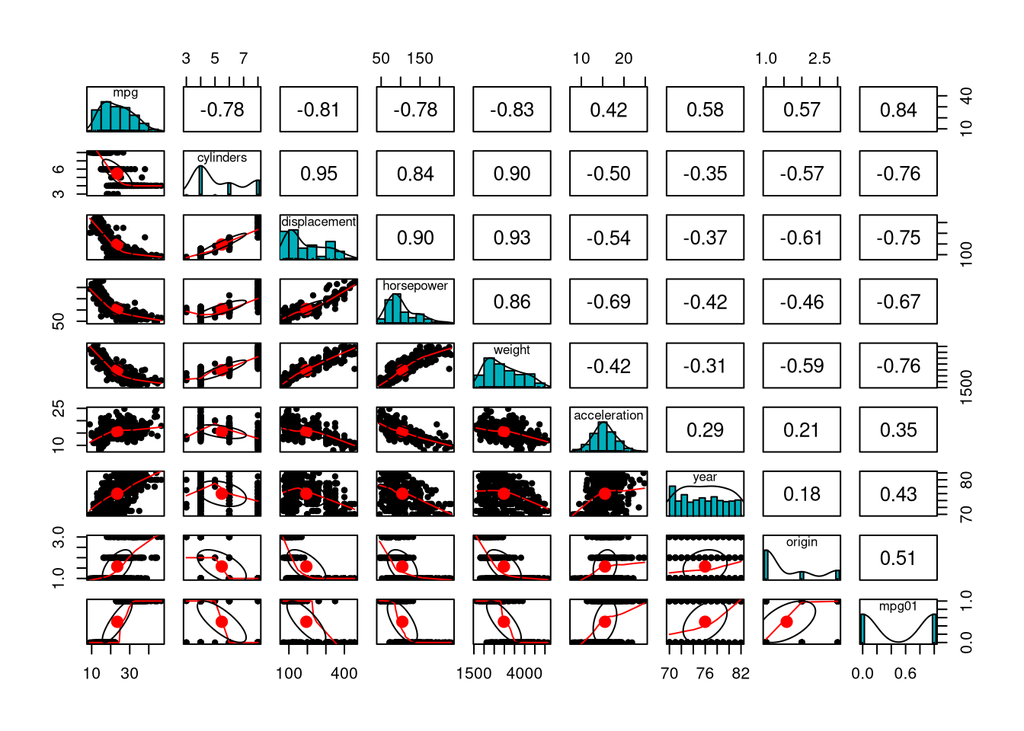

```r
# Sabiendo que name es un factor, lo excluimos del análisis

pairs.panels(Auto[,-9],
             method = "pearson",
             hist.col = "#00AFBB",
             density = TRUE,
             )
```

Podemos apreciar que existe una correlación negativa con las variables cylinders, displacement, horsepower y weight

```r
x <- sample(1:dim(Auto)[1], size=dim(Auto)[1]*0.75)
train <- Auto[x,]
test = Auto[-x,]
```

```r
autos.lda = lda(mpg01~displacement+weight+cylinders+horsepower, data=train)
autos.lda
```

```
## Call:
## lda(mpg01 ~ displacement + weight + cylinders + horsepower, data = train)
##
## Prior probabilities of groups:
##         0         1
## 0.5102041 0.4897959
##
## Group means:
##   displacement   weight cylinders horsepower
## 0     280.9067 3677.207  6.906667  132.32000
## 1     116.2118 2357.035  4.187500   79.59722
##
## Coefficients of linear discriminants:
##                        LD1
## displacement -0.0034795884
## weight       -0.0007103547
## cylinders    -0.5699944617
## horsepower    0.0070371363
```

```r
pred.lda <- predict(autos.lda, test, type="response")
matriz <- confusionMatrix(pred.lda$class, as.factor(test$mpg01))
matriz$table
```

```
##           Reference
## Prediction  0  1
##          0 34  1
##          1 12 51
```

```r
imprimirASS(matriz)
```

```
## [1] "Accuracy: 0.8673 Sensitivity: 0.7391 Specificity: 0.9808"
```

```r
autos.qda <- qda(mpg01 ~ cylinders + weight + displacement + horsepower, data = train)
autos.qda
```

```
## Call:
## qda(mpg01 ~ cylinders + weight + displacement + horsepower, data = train)
##
## Prior probabilities of groups:
##         0         1
## 0.5102041 0.4897959
##
## Group means:
##   cylinders   weight displacement horsepower
## 0  6.906667 3677.207     280.9067  132.32000
## 1  4.187500 2357.035     116.2118   79.59722
```

```r
pred.qda <- predict(autos.qda, test)
matriz <- confusionMatrix(pred.qda$class, as.factor(test$mpg01))
matriz$table
```

```
##           Reference
## Prediction  0  1
##          0 35  4
##          1 11 48
```

```r
imprimirASS(matriz)
```

```
## [1] "Accuracy: 0.8469 Sensitivity: 0.7609 Specificity: 0.9231"
```

```r
autos.glm <- glm(mpg01 ~ cylinders + weight + displacement + horsepower, data = train, family = binomial)
summary(autos.glm)
```

```
##
## Call:
## glm(formula = mpg01 ~ cylinders + weight + displacement + horsepower,
##     family = binomial, data = train)
##
## Deviance Residuals:
##     Min       1Q   Median       3Q      Max
## -2.6058  -0.1096  -0.0027   0.3348   3.5048
##
## Coefficients:
##                Estimate Std. Error z value Pr(>|z|)
## (Intercept)  11.7828810  2.0943714   5.626 1.84e-08 ***
## cylinders    -0.1735222  0.4096073  -0.424   0.6718
## weight       -0.0014219  0.0008382  -1.696   0.0898 .
## displacement -0.0166531  0.0098101  -1.698   0.0896 .
## horsepower   -0.0412833  0.0170405  -2.423   0.0154 *
## ---
## Signif. codes:  0 '***' 0.001 '**' 0.01 '*' 0.05 '.' 0.1 ' ' 1
##
## (Dispersion parameter for binomial family taken to be 1)
##
##     Null deviance: 407.45  on 293  degrees of freedom
## Residual deviance: 141.34  on 289  degrees of freedom
## AIC: 151.34
##
## Number of Fisher Scoring iterations: 7
```

```r
p <- predict(autos.glm, test, type = "response")
predichos=as.factor(ifelse(test = p > 0.5, yes = 1, no = 0))
verdaderos=as.factor(test$mpg01)
matriz<-confusionMatrix(predichos, verdaderos)
matriz$table
```

```
##           Reference
## Prediction  0  1
##          0 34  3
##          1 12 49
```

```
## [1] "Accuracy: 0.8469 Sensitivity: 0.7391 Specificity: 0.9423"
```

```r
train.X2 = cbind(train$displacement, train$weight, train$cylinders, train$year)
test.X2 = cbind(test$displacement, test$weight, test$cylinders, test$year)
train.Y2 = cbind(train$mpg01)
```

```r
# Para K = 10
pred.knn <- knn(train.X2, test.X2, train.Y2, k = 10)
z <-confusionMatrix(pred.knn, as.factor(test$mpg01))
z$table
```

```
##           Reference
## Prediction  0  1
##          0 36  4
##          1 10 48
```

```
## [1] "Accuracy: 0.8571 Sensitivity: 0.7826 Specificity: 0.9231"
```

```r
# Para K = 50
pred.knn <- knn(train.X2, test.X2, train.Y2, k = 50)
z <-confusionMatrix(pred.knn, as.factor(test$mpg01))
z$table
```

```
##           Reference
## Prediction  0  1
##          0 34  2
##          1 12 50
```

```
## [1] "Accuracy: 0.8571 Sensitivity: 0.7391 Specificity: 0.9615"
```

```r
# Para K = 100
pred.knn <- knn(train.X2, test.X2, train.Y2, k = 100)
z <-confusionMatrix(pred.knn, as.factor(test$mpg01))
z$table
```

```
##           Reference
## Prediction  0  1
##          0 34  2
##          1 12 50
```

```
## [1] "Accuracy: 0.8571 Sensitivity: 0.7391 Specificity: 0.9615"
```

Podemos ver que a partir de k = 10, la tasa de error se mantiene.

#### 12

```r
Power <- function() {
  2^3
}
Power()
```

```
## [1] 8
```

```r
Power2 <- function(x, a) {
  x^a
}
Power2(3,8)
```

```
## [1] 6561
```

```r
Power2(10,3)
```

```
## [1] 1000
```

```r
Power2(8,17)
```

```
## [1] 2.2518e+15
```

```r
Power2(131,3)
```

```
## [1] 2248091
```

```r
Power3 <- function(x , a) {
    result <- x^a
    return(result)
}
```

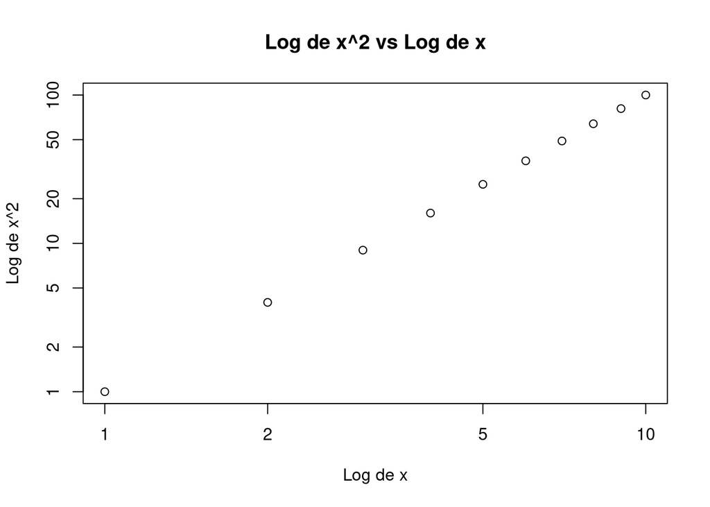

```r
x <- 1:10
plot(x, Power3(x, 2), log = "xy", xlab = "Log de x", ylab = "Log de x^2", main = "Log de x^2 vs Log de x")
```

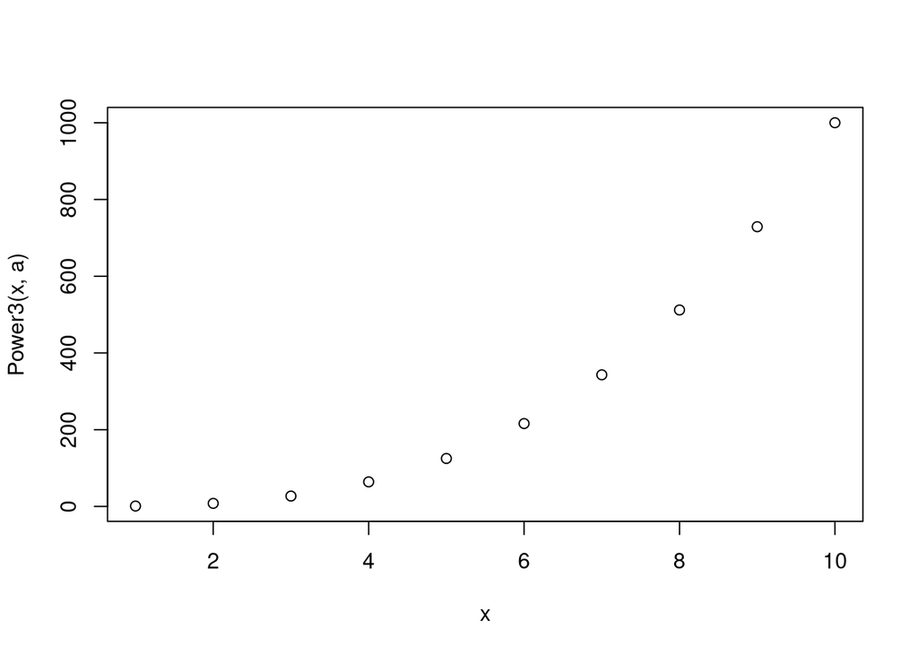

```r
PlotPower <- function(x, a) {
    plot(x, Power3(x, a))
}

PlotPower(1:10, 3)
```

#### 13

Se requiere usar la base de datos “Boston”, la cual a continuación podemos apreciar las variables que posee:

```r
str(Boston)
```

```
## 'data.frame':    506 obs. of  14 variables:
##  $ crim   : num  0.00632 0.02731 0.02729 0.03237 0.06905 ...
##  $ zn     : num  18 0 0 0 0 0 12.5 12.5 12.5 12.5 ...
##  $ indus  : num  2.31 7.07 7.07 2.18 2.18 2.18 7.87 7.87 7.87 7.87 ...
##  $ chas   : int  0 0 0 0 0 0 0 0 0 0 ...
##  $ nox    : num  0.538 0.469 0.469 0.458 0.458 0.458 0.524 0.524 0.524 0.524 ...
##  $ rm     : num  6.58 6.42 7.18 7 7.15 ...
##  $ age    : num  65.2 78.9 61.1 45.8 54.2 58.7 66.6 96.1 100 85.9 ...
##  $ dis    : num  4.09 4.97 4.97 6.06 6.06 ...
##  $ rad    : int  1 2 2 3 3 3 5 5 5 5 ...
##  $ tax    : num  296 242 242 222 222 222 311 311 311 311 ...
##  $ ptratio: num  15.3 17.8 17.8 18.7 18.7 18.7 15.2 15.2 15.2 15.2 ...
##  $ black  : num  397 397 393 395 397 ...
##  $ lstat  : num  4.98 9.14 4.03 2.94 5.33 ...
##  $ medv   : num  24 21.6 34.7 33.4 36.2 28.7 22.9 27.1 16.5 18.9 ...
```

Ahora calcularemos la mediana de la variiable crim para crear una nueva variable, la cual será binaria en donde 0 = crim <= mediana ó 1 = crim > mediana

```r
mediana_crim <- rep(0, length(Boston$crim))
mediana_crim[Boston$crim > median(Boston$crim)] <- 1
Boston$mediana_crim = mediana_crim
head(Boston)
```

```
##      crim zn indus chas   nox    rm  age    dis rad tax ptratio  black
## 1 0.00632 18  2.31    0 0.538 6.575 65.2 4.0900   1 296    15.3 396.90
## 2 0.02731  0  7.07    0 0.469 6.421 78.9 4.9671   2 242    17.8 396.90
## 3 0.02729  0  7.07    0 0.469 7.185 61.1 4.9671   2 242    17.8 392.83
## 4 0.03237  0  2.18    0 0.458 6.998 45.8 6.0622   3 222    18.7 394.63
## 5 0.06905  0  2.18    0 0.458 7.147 54.2 6.0622   3 222    18.7 396.90
## 6 0.02985  0  2.18    0 0.458 6.430 58.7 6.0622   3 222    18.7 394.12
##   lstat medv mediana_crim
## 1  4.98 24.0            0
## 2  9.14 21.6            0
## 3  4.03 34.7            0
## 4  2.94 33.4            0
## 5  5.33 36.2            0
## 6  5.21 28.7            0
```

Ahora construiremos nuestros datos de entrenamiento y de prueba

```r
set.seed(123)
train_index <- sample(1:nrow(Boston), 0.8 * nrow(Boston))
test_index <- setdiff(1:nrow(Boston), train_index)
```

```r
train <- Boston[train_index,0:length(Boston)]
test <- Boston[test_index,0:length(Boston)]
```

Ahora para entender un poco mejor las variables realizaremos un gráfico de dispersión y de correlaciones

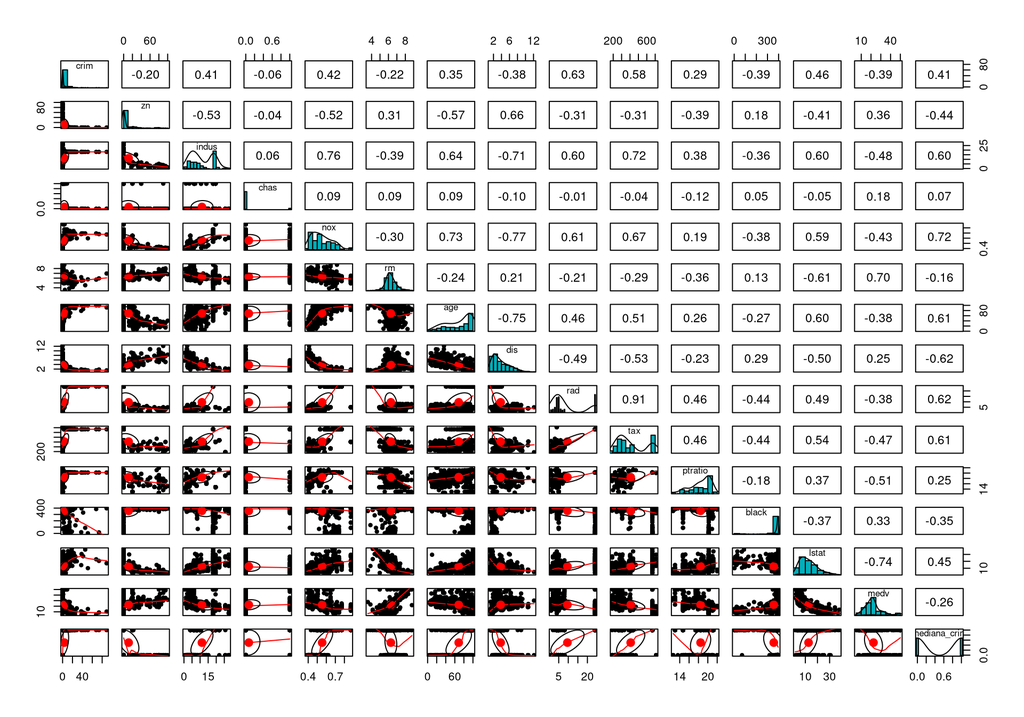

```r
pairs.panels(Boston,
             method = "pearson",
             hist.col = "#00AFBB",
             density = TRUE,
             )
```

Podemos apreciar que respecto a la variable mediana_crim, las variables nox, rad, dis, age, tax e indus son las que más están correlacionadas. Para este ejercicio se utilizarán modelos partiendo de una variable (la de mayor correlación) y se irán agregando nuevas variables para determinar cual es el mejor modelo para cada ténica.

Comenzando con modelos de regresión logística:

- Modelo con nox como única variable predictora

```r
glm_13.fit <- glm(mediana_crim ~ nox, data = train, family = binomial)
probs <- predict(glm_13.fit, test[,-15], type = "response")
predichos=as.factor(ifelse(test = probs > 0.5, yes = 1, no = 0))
verdaderos=as.factor(test[,15])
matriz<-confusionMatrix(predichos, verdaderos)
matriz$table
```

```
##           Reference
## Prediction  0  1
##          0 40  5
##          1  9 48
```

```
## [1] "Accuracy: 0.8627 Sensitivity: 0.8163 Specificity: 0.9057"
```

- Modelo con nox y rad como únicas variables predictoras

```r
glm_13.fit <- glm(mediana_crim ~ nox + rad, data = train, family = binomial)
probs <- predict(glm_13.fit, test[,-15], type = "response")
predichos=as.factor(ifelse(test = probs > 0.5, yes = 1, no = 0))
matriz<-confusionMatrix(predichos, verdaderos)
matriz$table
```

```
##           Reference
## Prediction  0  1
##          0 46  7
##          1  3 46
```

```
## [1] "Accuracy: 0.902 Sensitivity: 0.9388 Specificity: 0.8679"
```

- Modelo con nox, rad y dis como únicas variables predictoras

```r
glm_13.fit <- glm(mediana_crim ~ nox + rad + dis, data = train, family = binomial)
probs <- predict(glm_13.fit, test[,-15], type = "response")
predichos=as.factor(ifelse(test = probs > 0.5, yes = 1, no = 0))
matriz<-confusionMatrix(predichos, verdaderos)
matriz$table
```

```
##           Reference
## Prediction  0  1
##          0 46  7
##          1  3 46
```

```
## [1] "Accuracy: 0.902 Sensitivity: 0.9388 Specificity: 0.8679"
```

Como podemos apreciar en los anteriores modelos, con las variables nox y rad como únicas predictoras se obtuvo el mejor modelo, cuando agregamos más variables predictoras no se mejoran los resultados: Accuracy: 0.902 Sensitivity: 0.9388 Specificity: 0.8679

Ahora seguimos con los modelos LDA

- Modelo con nox como única variable predictora

```r
ldapre <- lda(mediana_crim ~ nox, data = train)
pred.lda <- predict(ldapre, test[,-15])
matriz<-confusionMatrix(pred.lda$class, verdaderos)
matriz$table
```

```
##           Reference
## Prediction  0  1
##          0 42 11
##          1  7 42
```

```
## [1] "Accuracy: 0.8235 Sensitivity: 0.8571 Specificity: 0.7925"
```

- Modelo con nox y rad como únicas variables predictoras

```r
ldapre <- lda(mediana_crim ~ nox + rad, data = train)
pred.lda <- predict(ldapre, test[,-15])
matriz<-confusionMatrix(pred.lda$class, verdaderos)
matriz$table
```

```
##           Reference
## Prediction  0  1
##          0 47 12
##          1  2 41
```

```
## [1] "Accuracy: 0.8627 Sensitivity: 0.9592 Specificity: 0.7736"
```

- Modelo con nox, rad y dis como únicas variables predictoras

```r
ldapre <- lda(mediana_crim ~ nox + rad + dis, data = train)
pred.lda <- predict(ldapre, test[,-15])
matriz<-confusionMatrix(pred.lda$class, verdaderos)
matriz$table
```

```
##           Reference
## Prediction  0  1
##          0 45 11
##          1  4 42
```

```
## [1] "Accuracy: 0.8529 Sensitivity: 0.9184 Specificity: 0.7925"
```

- Modelo con nox, rad, dis y age como únicas variables predictoras

```r
ldapre <- lda(mediana_crim ~ nox + rad + dis + age, data = train)
pred.lda <- predict(ldapre, test[,-15])
matriz<-confusionMatrix(pred.lda$class, verdaderos)
matriz$table
```

```
##           Reference
## Prediction  0  1
##          0 45 13
##          1  4 40
```

```
## [1] "Accuracy: 0.8333 Sensitivity: 0.9184 Specificity: 0.7547"
```

Podemos ver que aumentando el número de variables no presenta un mejora en la precisión de nuestro modelo, de lo que se probaron el mejor fue el que se usó con las variables nox y rad con los siguientes parámetros: Accuracy: 0.8627 Sensitivity: 0.9592 Specificity: 0.7736

Modelos KNN

```r
modelos_knn <- function(x_train, x_test, y_train, y_test, nk){
  pred.knn <- knn(x_train, x_test, y_train, k = nk)
  z <-confusionMatrix(pred.knn, y_test)
  print(paste0("K = ", nk))
  imprimirASS(z)
}
```

```r
entrenamiento.x <- as.matrix(train[,-15])
prueba.x <- as.matrix(test[,-15])
entrenamiento.y <- as.factor(train[,15])
prueba.y <- as.factor(test[,15])
```

```r
for (k in c(2:20)) {
  modelos_knn(entrenamiento.x, prueba.x, entrenamiento.y, prueba.y, k)
}
```

```
## [1] "K = 2"
## [1] "Accuracy: 0.9118 Sensitivity: 0.9184 Specificity: 0.9057"
## [1] "K = 3"
## [1] "Accuracy: 0.9216 Sensitivity: 0.9184 Specificity: 0.9245"
## [1] "K = 4"
## [1] "Accuracy: 0.9314 Sensitivity: 0.9388 Specificity: 0.9245"
## [1] "K = 5"
## [1] "Accuracy: 0.951 Sensitivity: 0.9796 Specificity: 0.9245"
## [1] "K = 6"
## [1] "Accuracy: 0.9314 Sensitivity: 0.9592 Specificity: 0.9057"
## [1] "K = 7"
## [1] "Accuracy: 0.9314 Sensitivity: 0.9592 Specificity: 0.9057"
## [1] "K = 8"
## [1] "Accuracy: 0.9314 Sensitivity: 0.9592 Specificity: 0.9057"
## [1] "K = 9"
```

[output cut: 23 more lines]

Podemos ver con un K = 5 se obtuvo la mayor precisión, lo cual también determina, que éste es el mejor modelo de todos los que se probaron en el ejercicio

### Capitulo 8

#### 7

```r
library(MASS)
library(randomForest)
```

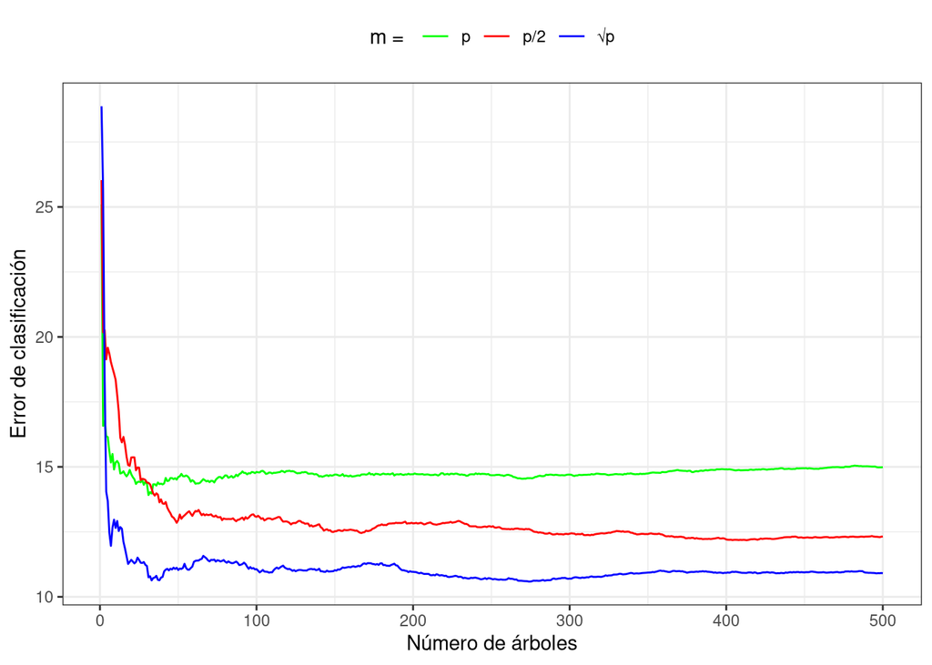

```r
set.seed(1)

train <- sample(1:nrow(Boston), 400)
Boston.train <- Boston[train, -14]
Boston.test <- Boston[-train, -14]
Y.train <- Boston[train, 14]
Y.test <- Boston[-train, 14]
boston1 <- randomForest(Boston.train, y = Y.train, xtest = Boston.test, ytest = Y.test, mtry = ncol(Boston) - 1, ntree = 500)
boston2 <- randomForest(Boston.train, y = Y.train, xtest = Boston.test, ytest = Y.test, mtry = (ncol(Boston) - 1) / 2, ntree = 500)
boston3 <- randomForest(Boston.train, y = Y.train, xtest = Boston.test, ytest = Y.test, mtry = sqrt(ncol(Boston) - 1), ntree = 500)

valores <- data.frame(c(1:500))
names(valores) <- "arboles"
valores["MSE1"] <- boston1$test$mse
valores["MSE2"] <- boston2$test$mse
valores["MSE3"] <- boston3$test$mse

library(ggplot2)
library(reshape2)
dd = melt(valores, id=c("arboles"))

theme_set(theme_bw())
ggplot(dd) + geom_line(aes(x=arboles, y=value, color=variable)) +
  scale_color_manual(name = "m = ",
                     labels = c("p","p/2","\u221Ap"),
                     values=c("green","red","blue")) +
  labs(x = "Número de árboles",
       y = "Error de clasificación") +
  theme(legend.position="top")
```

#### 8

```r
train <- sample(1:nrow(Carseats), 300)
Carseats.train <- Carseats[train, ]
Carseats.test <- Carseats[-train, ]
```

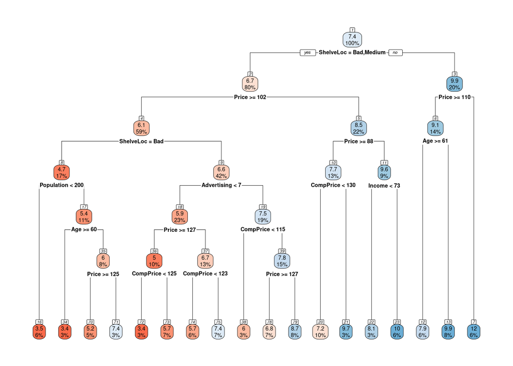

```r
library(rpart)
library(rpart.plot)

tree <- rpart(Sales~., data=Carseats.train)

rpart.plot(tree, box.palette="RdBu", nn=TRUE)
```

```r
yhat <- predict(tree, newdata = Carseats.test)
m1 <- mean((yhat - Carseats.test$Sales)^2)
m1
```

```
## [1] 4.197228
```

Como podemos apreciar el error MSE de la prueba es de 4.197228

```r
printcp(tree)
```

```
##
## Regression tree:
## rpart(formula = Sales ~ ., data = Carseats.train)
##
## Variables actually used in tree construction:
## [1] Advertising Age         CompPrice   Income      Population  Price
## [7] ShelveLoc
##
## Root node error: 2247.1/300 = 7.4904
##
## n= 300
##
##          CP nsplit rel error  xerror     xstd
## 1  0.211723      0   1.00000 1.01804 0.082943
## 2  0.123518      1   0.78828 0.80759 0.065671
## 3  0.057792      2   0.66476 0.71205 0.057322
## 4  0.039590      3   0.60697 0.68368 0.053027
## 5  0.032717      4   0.56738 0.67813 0.053775
## 6  0.026549      5   0.53466 0.66341 0.050763
## 7  0.021459      6   0.50811 0.62629 0.048310
## 8  0.018375      7   0.48665 0.63310 0.050340
## 9  0.017637      9   0.44990 0.64361 0.051830
## 10 0.017500     10   0.43226 0.64903 0.051778
## 11 0.015287     11   0.41476 0.62861 0.050278
## 12 0.014037     13   0.38419 0.62867 0.050364
## 13 0.013272     14   0.37015 0.64636 0.051480
## 14 0.012158     15   0.35688 0.64895 0.051655
## 15 0.011647     16   0.34472 0.64894 0.051919
## 16 0.010000     17   0.33308 0.64854 0.051978
```

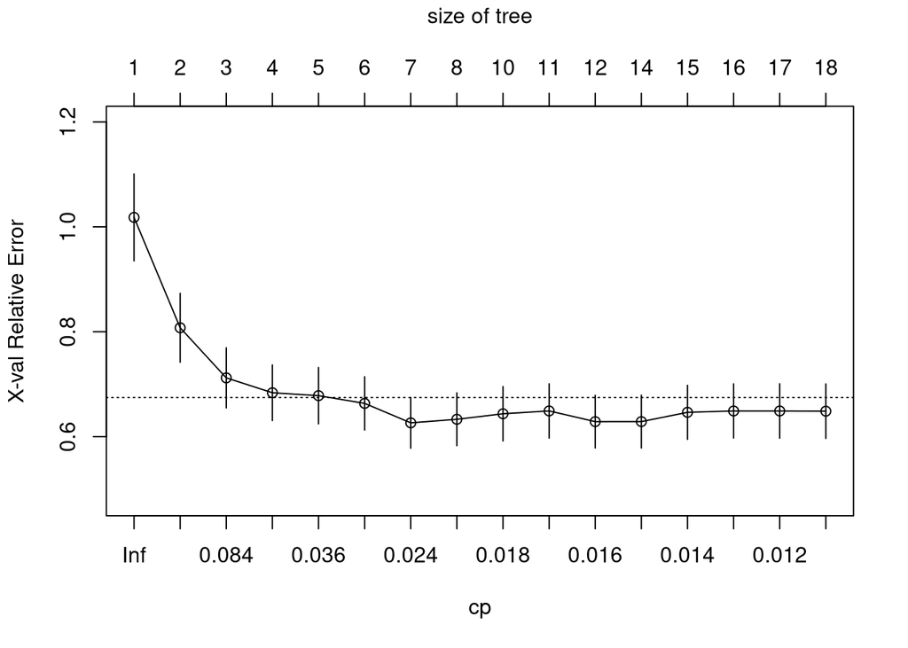

```r
plotcp(tree)
```

```r
min <- which.min(tree$cptable[,"xerror"])
min
```

```
## 7
## 7
```

```r
cp <-tree$cptable[which.min(tree$cptable[,"xerror"]),"CP"]
cp
```

```
## [1] 0.02145892
```

Con la validación cruzada obtenemos un tamaño de arbol igual a 7 y un cp de 0.02145892

```r
ptree<- prune(tree, cp= cp)
```

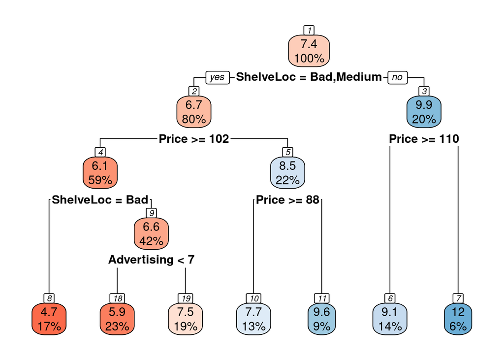

```r
rpart.plot(ptree, box.palette="RdBu", nn=TRUE)
```

```r
yhat <- predict(ptree, newdata = Carseats.test)
m2 <- mean((yhat - Carseats.test$Sales)^2)
m2
```

```
## [1] 4.54531
```

Podemos ver que se aumenta el MSE en nuestro caso después de la poda

```r
bag.carseats <- randomForest(Sales ~ ., data = Carseats.train, mtry = (ncol(Carseats) - 1), importance = TRUE)
yhat.bag <- predict(bag.carseats, newdata = Carseats.test)
mean((yhat.bag - Carseats.test$Sales)^2)
```

```
## [1] 2.381242
```

Podemos ver como se mejoró a 2.38 el MSE con este enfoque.

```r
importance(bag.carseats)
```

```
##               %IncMSE IncNodePurity
## CompPrice   38.928557    272.987960
## Income      11.725449    122.545479
## Advertising 14.937292    128.773274
## Population   2.518008     95.322579
## Price       71.644649    716.074862
## ShelveLoc   69.101715    596.025736
## Age         17.537409    167.453663
## Education    2.793162     64.343849
## Urban       -2.073262      8.985155
## US           4.206136      9.651551
```

Y con esto podemos apreciar que Price, ShelveLoc y CompPrice son las variables predictoras más importantes en este análisis

```r
bag.carseats <- randomForest(Sales ~ ., data = Carseats.train, mtry = sqrt((ncol(Carseats) - 1)), importance = TRUE)
yhat.bag <- predict(bag.carseats, newdata = Carseats.test)
mean((yhat.bag - Carseats.test$Sales)^2)
```

```
## [1] 2.80204
```

En este caso tenemos un MSE de 2.8

```r
importance(bag.carseats)
```

```
##                %IncMSE IncNodePurity
## CompPrice   16.2755940     216.47915
## Income       7.8217396     184.80927
## Advertising 14.1807157     183.03683
## Population   0.6892522     155.21205
## Price       42.0256227     551.81898
## ShelveLoc   47.8554474     473.99364
## Age         12.1305637     213.32128
## Education    2.8662179      91.35868
## Urban       -2.3838218      18.20191
## US           3.4288791      26.69131
```

También podemos ver que las variables más importantes siguen siendo las mismas que las que se declararon en el punto anterior.

#### 9

```r
train <- sample(1:nrow(OJ), 800)
OJ.train <- OJ[train, ]
OJ.test <- OJ[-train, ]
```

```r
library(tree)
tree.oj <- tree(Purchase ~ ., data = OJ.train)
summary(tree.oj)
```

```
##
## Classification tree:
## tree(formula = Purchase ~ ., data = OJ.train)
## Variables actually used in tree construction:
## [1] "LoyalCH"     "SalePriceMM" "SpecialCH"   "PriceDiff"
## Number of terminal nodes:  9
## Residual mean deviance:  0.707 = 559.3 / 791
## Misclassification error rate: 0.1512 = 121 / 800
```

Como podemos apreciar, el arbol tiene 9 nodos terminales y un error de entrenamiento de 0.1512. También podemos ver que las variables usadas en la construcción del árbol son LoyalCH, SalePriceMM, specialCH y PriceDiff

```r
tree.oj
```

```
## node), split, n, deviance, yval, (yprob)
##       * denotes terminal node
##
##  1) root 800 1065.00 CH ( 0.61625 0.38375 )
##    2) LoyalCH < 0.5036 351  424.90 MM ( 0.29345 0.70655 )
##      4) LoyalCH < 0.264232 151  102.10 MM ( 0.10596 0.89404 )
##        8) LoyalCH < 0.051325 57    0.00 MM ( 0.00000 1.00000 ) *
##        9) LoyalCH > 0.051325 94   85.77 MM ( 0.17021 0.82979 ) *
##      5) LoyalCH > 0.264232 200  273.90 MM ( 0.43500 0.56500 )
##       10) SalePriceMM < 2.04 109  126.30 MM ( 0.26606 0.73394 )
##         20) SpecialCH < 0.5 83   78.43 MM ( 0.18072 0.81928 ) *
##         21) SpecialCH > 0.5 26   35.89 CH ( 0.53846 0.46154 ) *
##       11) SalePriceMM > 2.04 91  119.20 CH ( 0.63736 0.36264 ) *
##    3) LoyalCH > 0.5036 449  349.40 CH ( 0.86860 0.13140 )
##      6) LoyalCH < 0.764572 188  217.80 CH ( 0.73404 0.26596 )
##       12) PriceDiff < 0.265 113  153.40 CH ( 0.58407 0.41593 )
##         24) PriceDiff < -0.165 34   41.19 MM ( 0.29412 0.70588 ) *
##         25) PriceDiff > -0.165 79   95.30 CH ( 0.70886 0.29114 ) *
##       13) PriceDiff > 0.265 75   25.19 CH ( 0.96000 0.04000 ) *
##      7) LoyalCH > 0.764572 261   78.30 CH ( 0.96552 0.03448 ) *
```

Se escoge el nodo terminal 7, en este podemos apreciar que su creterio de división es LoyalCH > 0.764572, éste tiene 261 observaciones en este nodo con una desviación de 78.30. La predicción en este nodo es Sales = CH, también podemos ver que el 96.552% de las observaciones toman el valor de CH, mientras que el 3.448% toman el valor de MM.

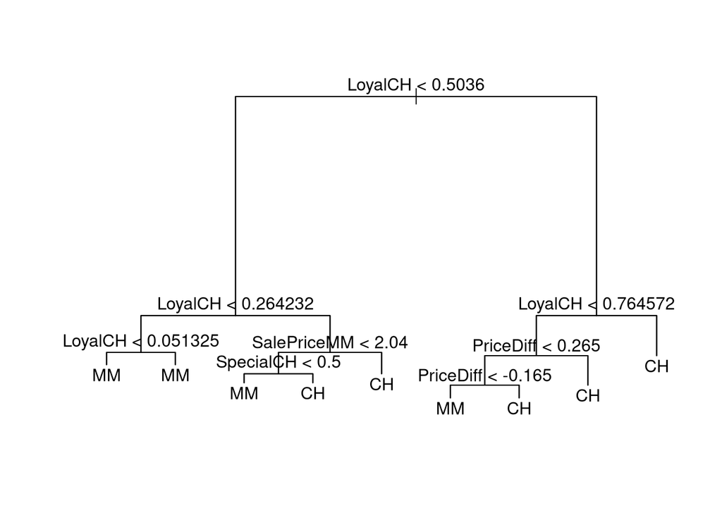

```r
plot(tree.oj)
text(tree.oj, pretty = 0)
```

En este caso podemos apreciar que la variable principal es LoyalCH, los nodos que nacen de este también usan LoyalCH para dividir el arbol. Podemos ver que en el nodo principal si LoyalCH es mayor o igual a 0.5036, sólo se usa PriceDiff como otra variable, mientras en caso contrario se utilizan las variables salePriceMM y SpecialCH.

```r
tree.pred <- predict(tree.oj, OJ.test, type = "class")

matriz<-confusionMatrix(tree.pred, OJ.test$Purchase)
matriz
```

```
## Confusion Matrix and Statistics
##
##           Reference
## Prediction  CH  MM
##         CH 144  34
##         MM  16  76
##
##                Accuracy : 0.8148
##                  95% CI : (0.7633, 0.8593)
##     No Information Rate : 0.5926
##     P-Value [Acc > NIR] : 4.577e-15
##
##                   Kappa : 0.6064
##
##  Mcnemar's Test P-Value : 0.01621
##
##             Sensitivity : 0.9000
##             Specificity : 0.6909
##          Pos Pred Value : 0.8090
##          Neg Pred Value : 0.8261
##              Prevalence : 0.5926
##          Detection Rate : 0.5333
##    Detection Prevalence : 0.6593
##       Balanced Accuracy : 0.7955
##
##        'Positive' Class : CH
##
```

Podemos ver que la precisión del modelo es de 81.48%, siendo mucho más preciso para predecir CH con un 90% mientras que para predecir MM sólo es de un 69.09%.

```r
cv.oj <- cv.tree(tree.oj, FUN = prune.misclass)
cv.oj
```

```
## $size
## [1] 9 8 7 4 2 1
##
## $dev
## [1] 135 135 140 151 172 303
##
## $k
## [1]       -Inf   0.000000   2.000000   4.666667  12.500000 145.000000
##
## $method
## [1] "misclass"
##
## attr(,"class")
## [1] "prune"         "tree.sequence"
```